# REAME: SARS-CoV-2 sequence submission process

Mandy Waters

CDPHE Contractor

July 2021

### Goals

Provide a detailed overview of SARS-CoV-2 submissions to GISAID, NCBI BioSample, NCBI SRA, and NCBI GenBank. This document will take CDPHE colleagues through initial set up on a GCP VM running Ubuntu 18.04, process / pipeline flow, and scripts developed to automate metadata genereation. Scripts are availble on the CDPHE [Github](https://github.com/CDPHE/seq-submission-metadata-R). This section will cover the following items:

1. Getting set up with software and accounts (GISAID and NCBI)
2. High level overview and process
3. General information

### Set up and software

#### Overview

Users will need to create accounts with GISAID and NCBI, install software, and complete some prliminary steps before running the sequence submission pipeline. Please follow all instructions in subsequent tabs to get set up.

#### GISAID Account

Navigate to GISAID's registration page: [link](https://www.gisaid.org/registration/register/).  
Click on the 'register' button on the bottom right corner of the page. Fill in with your personal and CDPHE info:

Institution: Colorado Department of Public Health and Environment  
Department: Microbiology  
Address: 8100 E Lowry Blvd Denver CO 80230  
email: CDPHE email

They will send you an email to confirm your registration with a link you need to click on. Then you will get another email confirming your successful registration.

#### NCBI Account

NCBI has a new login method where you use your gmail (CDPHE email) to sign in and authenticate. Make sure the keychain for your browser is for your CDPHE email otherwise it will error out. I had some intermitent issues getting proxy errors and such, but kept refreshing until it worked. Follow the instructions given by NCBI to create a new account. NCBI will send you a confirmation email once they've processed your request.

Navigate to NCBI's registration page: [link](https://account.ncbi.nlm.nih.gov/signup/).

Institution: Colorado Department of Public Health and Environment  
Department: Microbiology  
Address: 8100 E Lowry Blvd Denver CO 80230  
email: CDPHE email  
back-up email: personal email

#### Software

Programs to download/install on your VM for the submission process:  
1. [Atom](https://flight-manual.atom.io/getting-started/sections/installing-atom/) - or your other favorite Linux Text Editor  
2. [Seqtk](https://github.com/lh3/seqtk): parsing and editing fasta files. Link takes you to a github repo with a readme  
3. [SeqKit](https://bioinf.shenwei.me/seqkit/download/): parsing and editing fasta files  
4. [VADR](https://github.com/StaPH-B/staphb_toolkit): is part of the staphb-tk that you installed in the Getting Started document  
5. [MAFFT](https://mafft.cbrc.jp/alignment/software/linux.html): MSA. Molly's version of indel_finder as of Sept 3, 2021 runs MAFFT pairwise for each sample in your batch, but might be good to have a local copy  
6. [IGV](https://software.broadinstitute.org/software/igv/download): checking read coverage  
7. [Indel_finder.py](https://github.com/CDPHE/sars-cov-2_indel_finder): is on the CDPHE github page  
8. Samtools: working and indexing alignment (bam) files

```bash
# I have conda installed and therefore was able to install samtools with conda
conda install -c bioconda samtools
```

9. Aspera Connect Ascp: gsutil cp -r gs://laura-sandbox/aspera-connect/ . Then you can find ascp in aspera/connect/bin. You might need to make the ascp file executable by running chmod +x aspera/connect/bin/ascp
10. [Aliview](https://ormbunkar.se/aliview/#DOWNLOAD) - review MSA. After install you can open 'aliview' by just typing aliview on your VM terminal
11. rename_fasta.py: might be good to have, but Molly's modifications to indel_finder as of Sept 3, 2021 takes in multi-fasta, so this script isn't needed. Can be accessed using: gsutil cp gs://laura-terra/rename_fasta.py .

### Overview of process

Below is a flowchart showing the major steps in submitting SARS-CoV-2 samples to GISAID and NCBI. A ppt version of this diagram can be found the CDPHE [Github](https://github.com/CDPHE/seq-submission-metadata-R) as seq_upload_flowchart.pptx

[figure not shown]

### General information

#### Finding data

Special call out to Laura Bankers for most of the content below

**Overview:** All sequencing data, intermediate files, alignments (bam files), and assemblies are stored in the google bucket gs://covid_terra in the SNP Linux project on GCP. Inside that bucket, there is a directory for each sequencing run, and inside that directory are all of the raw data and necessary files for every sample sequenced on that run. Sequencing run directories are named based on the platform + run id number. Those beginning with COVSEQ_ are paired-end Illumina Miseq runs, those beginning with COVMIN_ are Oxford Nanopore GridION runs, NEXSEQ_ are single-end NextSeq runs, and COVARC are archived samples from earlier in the pandemic that we are now going back to and are sequenced on either MiSeq or GridION. The numbers after the underscore are the run id numbers (e.g. COVMIN_0009 is nanopore run 0009). For submissions you will need the consensus genome fasta files, the raw reads, and the metadata. If you need to go back and check the validity of some SNP or indels calls, you may also need to bam files

**Metadata:** For all COVMIN and NEXSEQ runs, and all COVSEQ runs from COVSEQ_0062rq and greater, metadata is found in the results_RUNNAME_RUNDATE file e.g. (results_COVMIN_0009_2021-04-27), which are pushed and can be downloaded from a shared Google Drive

**Consensus genome fasta files:** the final consensus genome fasta files to be submitted are named accessionid_renamed_consensus.fa (e.g. 2100213088_consensus_renamed.fa) and is located in gs://covid_terra/run_directory/terra_outputs/assemblies/ (e.g. gs://covid_terra/COVMIN_0009/terra_outputs/assemblies/)

**Raw reads:** For Illumina MiSeq and NextSeq runs (COVSEQ and NEXSEQ), raw reads for each sample on the run can be found in gs://covid_terra/COVSEQ_NNNN/fastq_files/. For nanopore runs (COVMIN), the fastq files for each sample are in separate directories that are named based on each samples barcode (e.g. gs:// covid_terra/COVMIN_0009/fastq_pass/barcode02), which need to be merged together (script built to do this)

**Bam files:** bam files can be found in gs:// covid_terra/SEQRUN_NNNN/terra_outputs/alignments (e.g. gs:// covid_terra/COVMIN_0009/terra_outputs/alignments)

**Samples that have been re-run / resequenced:** Some samples needed to be resequenced. A list of these samples can be found [here](https://docs.google.com/spreadsheets/d/1PtaHHa8iuqM6fNGTSkHiinxc5poQnVt1Ti67yLSVQ6c/edit#gid=471638297). This file will need to be downloaded before each submission so samples are not submitted more than once and the resequenced samples are being uploaded.

**Extra information:**

1. early COVMIN runs were re-analyzed due to workflow updates. The final results for these runs are in “terra_outputs_rr” (be sure to use files in the _rr directories in these cases). The underlying directory structure in the _rr directory is the same as the other output directories
2. NCBI BioSample only lets you submit up to 1000 samples at a time – So I tend to just maintain batch numbers of up to 1000 sample throughout the entire process
3. GenBank only allows you to select a single sequencing technology for an entire submission. So only include a single sequencing platform in a given batch (i.e. up to 1000 sample from only Illumina MiSeq runs)

#### Tracking submissions

Laura has created an [excel document](https://docs.google.com/spreadsheets/d/1n9NzJNrqIHP9Lct_MZuSnOv3Qn1JCZsI/edit#gid=331506794) to track which projects / batches have not been submitted, are in process, and are completed as well as tabs that outlines metadata sheets necessary for GISAID, BioSample, SRA, and GenBank (R scripts make these).

Sumbitters can add their initals next to the projects they are working on in the in the 'Notes' column in 'NOT_submitted' tab to ensure mulitple submitters aren't working on the same projects. While we are catching up we are submitting samples we are having GenBank reject samples when they find errors. Add these samples to the 'ONGOING_submissions' tab and we will go back when we are more caught up. Once the samples are submitted to all public databases then all concatted metadata are put into the 'COMPLETED_submissions' tab.

#### Download re-run samples

The sequencing center adds information about which samples were rerun on the CDPHE Google Drive. You can download the re-run tab from 'List_of_bad_runs_and_waste_water_samples' google sheet using the instructions below.

1. Navigate to the [Google Sheet](https://docs.google.com/spreadsheets/d/1PtaHHa8iuqM6fNGTSkHiinxc5poQnVt1Ti67yLSVQ6c/edit#gid=471638297) - if you can't reach this site then one of the current contributors with edit access to share the file with you.
2. Click File -> Download -> tab-separated values (tsv, current sheet)
3. Once downloaded run the following command to pseudo track versions - this adds the date and gets rid of spaces

```bash
mv List_of_bad_runs_and_waste_water_samples\ -\ re-run_samples.tsv rerun_samples_$(date +%d%b%Y).tsv
```

#### Download completed list

Some samples will be sequenced more than once on different sequencing platform (didn't fail, so they won't be in the rerun / bad noodle samples). To account for this users should also download a copy of the COMPLETED_submissions' tab in submissions_and_compiled_metadata

1. Navigate to the [Google sheet](https://docs.google.com/spreadsheets/d/1n9NzJNrqIHP9Lct_MZuSnOv3Qn1JCZsI/edit#gid=331506794) - if you can't reach this site then one of the current contributors with edit access to share the file with you.
2. Click File -> Download -> tab-separated values (tsv, current sheet)
3. Once downloaded run the following command to pseudo track versions - this adds the date and gets rid of spaces

```bash
mv SUBMISSIONS_and_compiled_metadata.xlsx\ -\ COMPLETED_submissions_metadata.tsv completed_submissions_$(date +%d%b%Y).tsv
```

#### Download on-going list

Some samples will be rejected by NCBI Genbank, but will be submitted to GISAID, BioSample, and SRA, so we will also want to delete these out of your current submission as GISAID and NCBI (BioSample and SRA) will reject them. Users should download a copy of the 'ONGOING_submissions' tab in submissions_and_compiled_metadata

1. Navigate to the [Google sheet](https://docs.google.com/spreadsheets/d/1n9NzJNrqIHP9Lct_MZuSnOv3Qn1JCZsI/edit#gid=80251444) - if you can't reach this site then one of the current contributors with edit access to share the file with you.
2. Click File -> Download -> tab-separated values (tsv, current sheet)
3. Once downloaded run the following command to pseudo track versions - this adds the date and gets rid of spaces

```bash
mv SUBMISSIONS_and_compiled_metadata.xlsx\ -\ ONGOING_submissions.tsv ongoing_submissions_$(date +%d%b%Y).tsv
```

#### GISAID submission

Submit your sequence to GISAID

1. The metadata file needed will be written by the R script gisaid_ncbi_biosample_metadata_formatting.R with all columns headers with missing data for any fields that we don’t fill out
2. Login to your [GISAID account](https://www.gisaid.org/), then go to the EpiCoV tab, then select > batch upload (you can ignore the CLI notification window that will pop up because the standard submission method is super easy. Upload your metadata csv, upload your fasta, and select “check and submit"
3. You will receive an email once your sequences have been processed with those that have been released and another if GISAID finds any errors. They will either ask you to email them back with coverage information or respond by accessing the 'unreleased' tab on your GISAID account (more recently the latter is more common). If the frameshift mutations don't match something that was already flagged by VADR, then check the bam file in IGV. Write out a new fasta file with the consensus sequences that were rejected (corrected and unchanged sequences if coverage supports the nucleotide seq) and replace this new fasta in the upload page on GISAID.

   Note that the email you get once the data are processed will contain all the GISAID accessions, but it will not say what samples they are linked to, so to get that information as well as Pangolin/Nextclade lineage information, you will need to go back to your gisaid account > search > fill in the submission date, and then download sequence technology metadata file.

#### BioSample submission info

Submit to NCBI BioSample

1. Get metadata file made from gisaid_ncbi_biosample_metadata_formatting.R. Make sure you use BioProject PRJNA686984.
2. Login to NCBI and go the submission portal: https://submit.ncbi.nlm.nih.gov/subs/
3. Go to My Submissions > BioSample > New Submission
4. Fill out the submitter info with your state email as the primary email and fill out institutional information as follows:

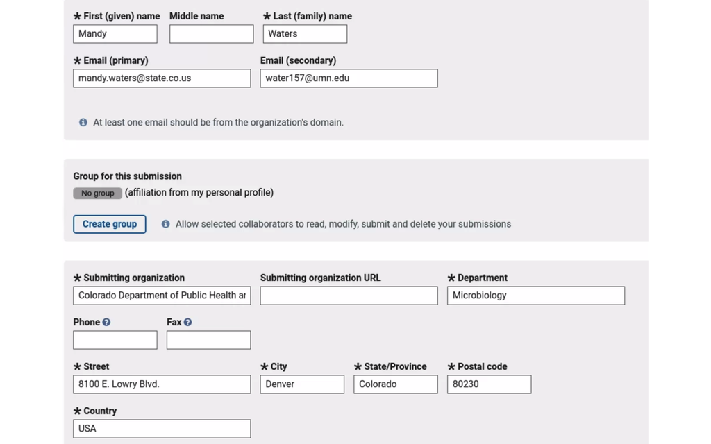

6. Under General Information select:
   - “Release immediately following processing”
   - “BatchMultiple BioSamples” **Note that you are only allowed to submit up to 1000 Biosamples at a time
7. Under Sample Template select “SARS-CoV-2: clinical or host-associated”
8. Under Attributes you will upload your metadata tsv file
9. Under Review and Submit, double check that everything looks correct and then hit submit

Once your BioSample submission has been fully processed, you can proceed to NCBI SRA submission (you will need for BioSample SAMNNNNNNNN accession ids for SRA) – this generally takes less than an hour.